# Wine EDA report

2022-06-15

**Information about the data** this data set has 12 columns as showing here

```r
 colnames(wine)
```

```
##  [1] "fixed.acidity"        "volatile.acidity"     "citric.acid"
##  [4] "residual.sugar"       "chlorides"            "free.sulfur.dioxide"
##  [7] "total.sulfur.dioxide" "density"              "pH"
## [10] "sulphates"            "alcohol"              "quality"
```

the data are , ’*fixed acidity* : which is the most acids involved with wine

*volatile acidity*: the amount of acetic acid in wine, which at too high of levels can lead to an unpleasant, vinegar taste

*citric acid*: found in small quantities, citric acid can add ‘freshness’ and flavor to wines

*residual sugar*: the amount of sugar remaining after fermentation stops, it’s rare to find wines with less than 1 gram/liter and wines with greater than 45 grams/liter are considered sweet

*chlorides*: the amount of salt in the wine

*free sulfur dioxide*: the free form of SO2 exists in equilibrium between molecular SO2 (as a dissolved gas) and bisulfite ion; it prevents microbial growth and the oxidation of wine

*total sulfur dioxide*: amount of free and bound forms of S02; in low concentrations, SO2 is mostly undetectable in wine, but at free SO2 concentrations over 50 ppm, SO2 becomes evident in the nose and taste of wine

*density*: the density of water is close to that of water depending on the percent alcohol and sugar content

*pH*: describes how acidic or basic a wine is on a scale from 0 (very acidic) to 14 (very basic); most wines are between 3-4 on the pH scale

*sulphates*: a wine additive which can contribute to sulfur dioxide gas (S02) levels, wich acts as an antimicrobial and antioxidant

*alcohol*: the percent alcohol content of the wine *quality* : the rate of the quality ’[sourse](https://rstudio-pubs-static.s3.amazonaws.com/57835_c4ace81da9dc45438ad0c286bcbb4224.html#:~:text=1%20%2D%20fixed%20acidity%3A%20most%20acids,to%20an%20unpleasant%2C%20vinegar%20taste)

to see a first insight to the data it self

WINE EDA

a better look at WINE table

| fixed.acidity | volatile.acidity | citric.acid | residual.sugar | chlorides | free.sulfur.dioxide | total.sulfur.dioxide | density | pH | sulphates | alcohol | quality |
| --- | --- | --- | --- | --- | --- | --- | --- | --- | --- | --- | --- |
| 7.4 | 0.70 | 0.00 | 1.9 | 0.076 | 11 | 34 | 0.9978 | 3.51 | 0.56 | 9.4 | 5 |
| 7.8 | 0.88 | 0.00 | 2.6 | 0.098 | 25 | 67 | 0.9968 | 3.20 | 0.68 | 9.8 | 5 |
| 7.8 | 0.76 | 0.04 | 2.3 | 0.092 | 15 | 54 | 0.9970 | 3.26 | 0.65 | 9.8 | 5 |
| 11.2 | 0.28 | 0.56 | 1.9 | 0.075 | 17 | 60 | 0.9980 | 3.16 | 0.58 | 9.8 | 6 |
| 7.4 | 0.70 | 0.00 | 1.9 | 0.076 | 11 | 34 | 0.9978 | 3.51 | 0.56 | 9.4 | 5 |
| 7.4 | 0.66 | 0.00 | 1.8 | 0.075 | 13 | 40 | 0.9978 | 3.51 | 0.56 | 9.4 | 5 |
| 7.9 | 0.60 | 0.06 | 1.6 | 0.069 | 15 | 59 | 0.9964 | 3.30 | 0.46 | 9.4 | 5 |
| 7.3 | 0.65 | 0.00 | 1.2 | 0.065 | 15 | 21 | 0.9946 | 3.39 | 0.47 | 10.0 | 7 |
| 7.8 | 0.58 | 0.02 | 2.0 | 0.073 | 9 | 18 | 0.9968 | 3.36 | 0.57 | 9.5 | 7 |
| 7.5 | 0.50 | 0.36 | 6.1 | 0.071 | 17 | 102 | 0.9978 | 3.35 | 0.80 | 10.5 | 5 |

this show us two things 1- all variable are double except quality is integer 2- the table is not that consistent and need some clean one way to do that is using `janitor` package

```r
wine %>% clean_names() -> wine
```

this function will clean columns , remove spaces and convert it to lower case (snake case)

now lets look more into the data

```r
summary(wine)
```

```
##  fixed_acidity   volatile_acidity  citric_acid    residual_sugar
##  Min.   : 4.60   Min.   :0.1200   Min.   :0.000   Min.   : 0.900
##  1st Qu.: 7.10   1st Qu.:0.3900   1st Qu.:0.090   1st Qu.: 1.900
##  Median : 7.90   Median :0.5200   Median :0.260   Median : 2.200
##  Mean   : 8.32   Mean   :0.5278   Mean   :0.271   Mean   : 2.539
##  3rd Qu.: 9.20   3rd Qu.:0.6400   3rd Qu.:0.420   3rd Qu.: 2.600
##  Max.   :15.90   Max.   :1.5800   Max.   :1.000   Max.   :15.500
##    chlorides       free_sulfur_dioxide total_sulfur_dioxide    density
##  Min.   :0.01200   Min.   : 1.00       Min.   :  6.00       Min.   :0.9901
##  1st Qu.:0.07000   1st Qu.: 7.00       1st Qu.: 22.00       1st Qu.:0.9956
##  Median :0.07900   Median :14.00       Median : 38.00       Median :0.9968
##  Mean   :0.08747   Mean   :15.87       Mean   : 46.47       Mean   :0.9967
##  3rd Qu.:0.09000   3rd Qu.:21.00       3rd Qu.: 62.00       3rd Qu.:0.9978
##  Max.   :0.61100   Max.   :72.00       Max.   :289.00       Max.   :1.0037
##       p_h          sulphates         alcohol         quality
##  Min.   :2.740   Min.   :0.3300   Min.   : 8.40   Min.   :3.000
##  1st Qu.:3.210   1st Qu.:0.5500   1st Qu.: 9.50   1st Qu.:5.000
##  Median :3.310   Median :0.6200   Median :10.20   Median :6.000
##  Mean   :3.311   Mean   :0.6581   Mean   :10.42   Mean   :5.636
##  3rd Qu.:3.400   3rd Qu.:0.7300   3rd Qu.:11.10   3rd Qu.:6.000
##  Max.   :4.010   Max.   :2.0000   Max.   :14.90   Max.   :8.000
```

we can see the range in `acidity` and `sugar` is high the median in `sugar` is 2.2 and the max is 15 but for `acidity` the mean is between the max and the min the `density` has narrow range ——

**EDA**

first thing after I saw the summary I need to see the correlation

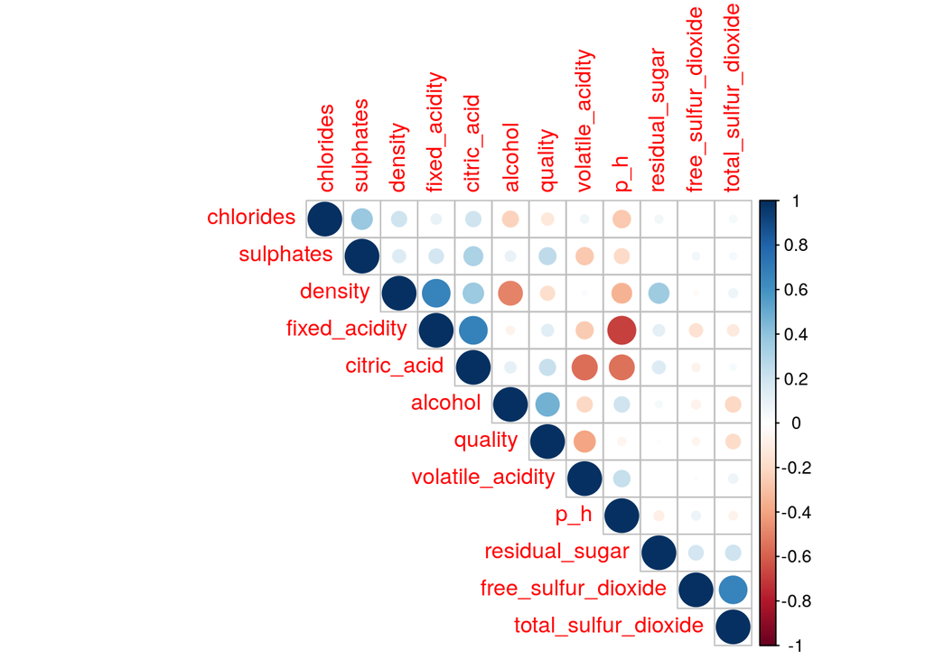

```r
wineCor <-cor(wine)
corrplot(wineCor, type="upper", order="hclust",  )
```

> the plot shows that there are a relation between quality and volatile acidity the plot shows that there are a relation between fixed acidity and PH and many other

what i want to see is the relation between the quality and volatile acidity one way is to see the ranges between them and how they are correlate to each other and what kind of correlation it is

a good approach to see the range is using a box plot

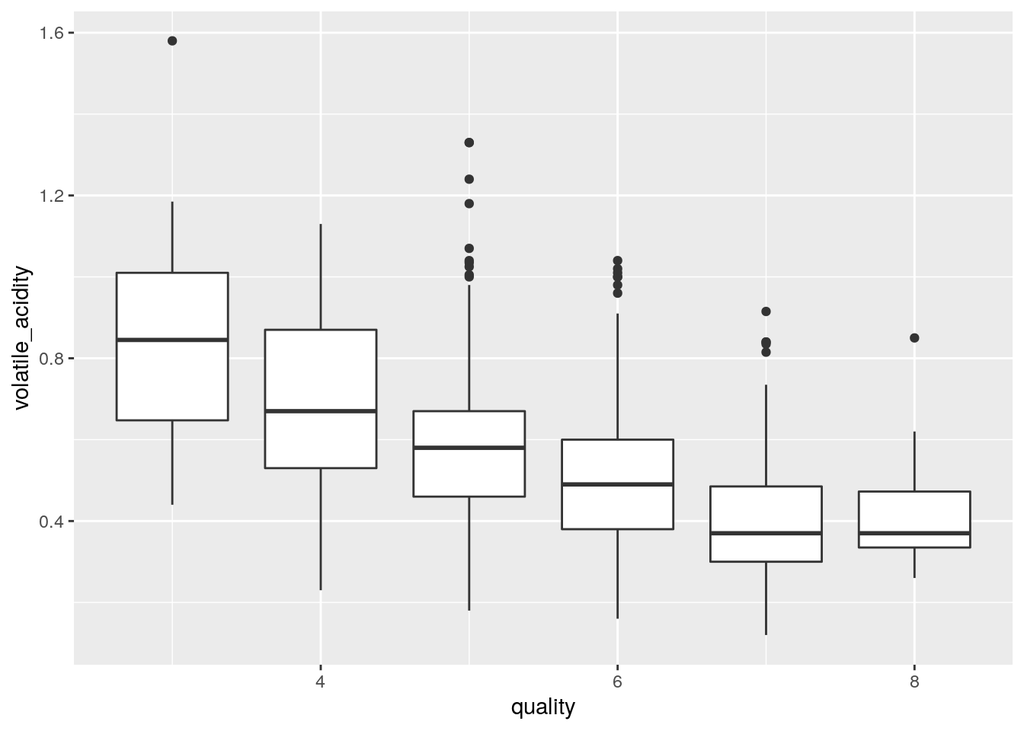

```r
wine %>%
  ggplot(aes(x= quality , y = volatile_acidity)) +geom_boxplot(aes(group = cut_width(quality, 0.25)))
```

this shows that the higher the the quality we will have a lower ranges another thing this plot show is that the higher the the quality the box go down i seems that it is right skewed to confirm that i made a bar plot

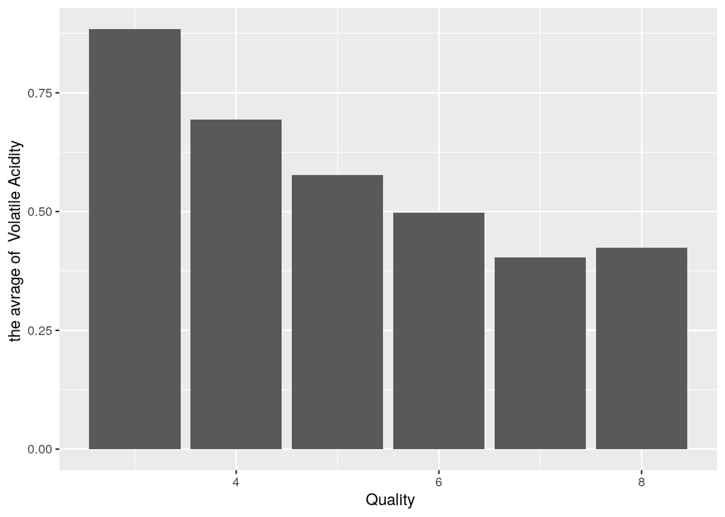

```r
wine %>%
  group_by(quality) %>%
  summarise(AVG = mean(volatile_acidity)) %>%
  ggplot(aes(x =quality  , y= AVG)) +
  geom_bar(stat='identity')+ ##  identity will provide the y-values for the barplot, rather than counting the aggregate number
  labs(y="the avrage of  Volatile Acidity ", x=" Quality")
```

this make it obvious that the relation is right skewed

another correlation there are is the `fixed_aced` and `p_h` . we can’t make box plot to find the ranges since there both quantitative data so a better way to see the relation is using scatterplots

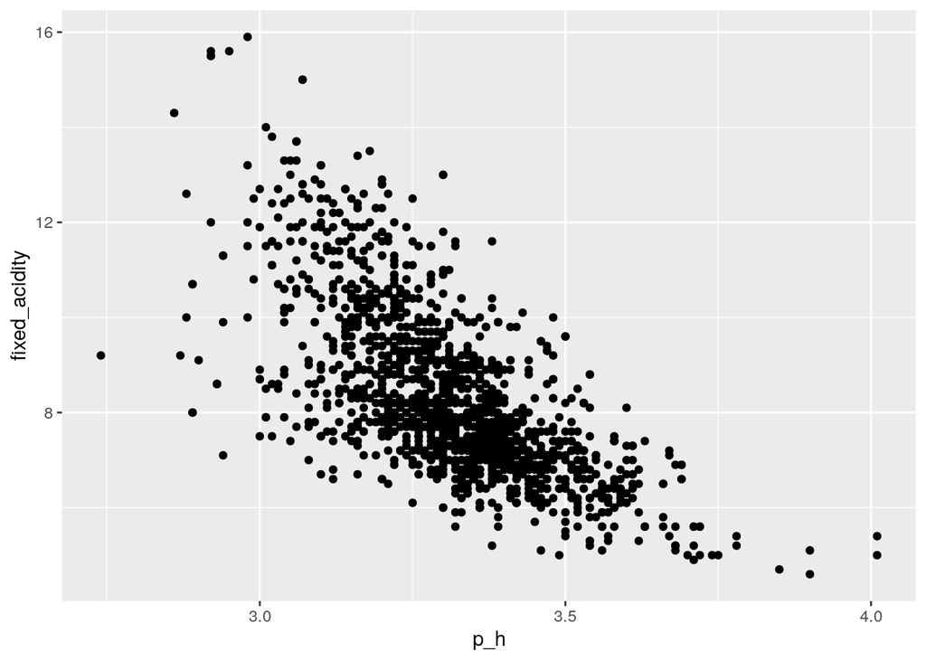

```r
wine %>%
ggplot(aes(x= p_h , y = fixed_acidity)) + geom_point()
```

this shows the relation very clear that it is a negative relation.

the correlation graph also shows that there is a relation between the p_h and citric_acid by the same idea above

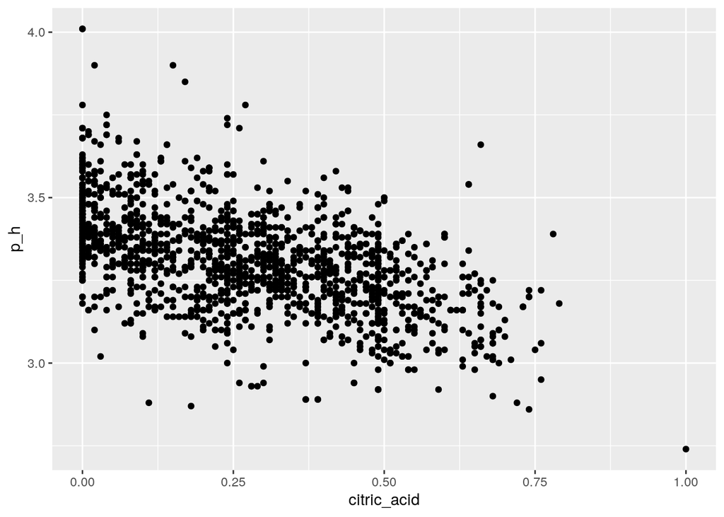

```r
wine %>%
ggplot(aes(x=  citric_acid, y = p_h)) + geom_point()
```

what is the most used quality ?

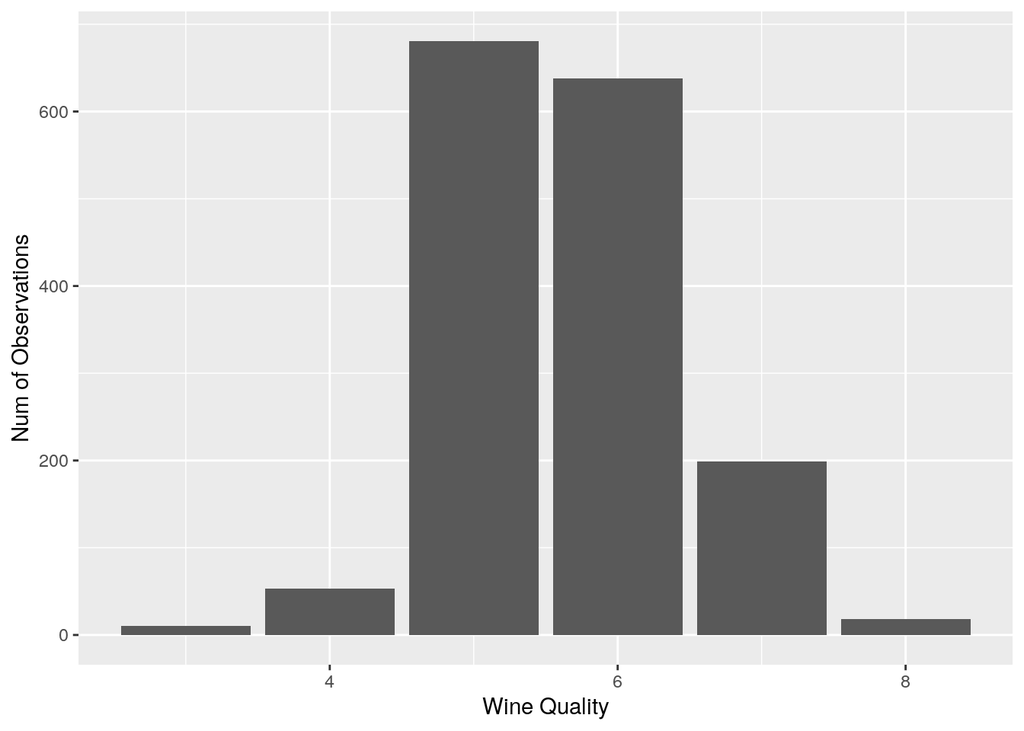

```r
ggplot(wine, aes(x=quality )) +
  geom_bar() +
  labs(y="Num of Observations", x="Wine Quality")
```

**Conclusion**

from this data we can cunclude that : > 1- range in `acidity` and `sugar` is high > 2- the difrence between median in `sugar` maximmum is high > 3- the higher the the quality we will have a lower ranges > 4- the relation between quality and volatile acidity is right skewed > 5- the relation between `fixed_aced` and `p_h` is negative relation > 6- the quality trend is by far the average quality